# STPGA Package Demo Report

Deniz Akdemir

2025-07-27

# STPGA Package v7.0.0 Demo

This document demonstrates the modernized STPGA package functionality using the included WheatData dataset.

## Package Overview

The STPGA package provides advanced genetic algorithms for optimal subset selection in genomic prediction and experimental design. Version 7.0.0 introduces significant enhancements including multi-criteria convergence detection, restart mechanisms, and enhanced selection methods.

### New Features in v7.0.0

- **Enhanced Convergence Detection**: Multi-criteria monitoring of fitness, diversity, and improvement rates
- **Restart Mechanisms**: Automatic detection and recovery from premature convergence
- **Advanced Selection Methods**: Rank-based selection with configurable pressure control
- **Convergence Diagnostics**: Comprehensive analysis and optimization recommendations
- **Parameter Validation**: Automatic correction of invalid parameters with user warnings

For detailed coverage of these features, see the “Advanced Genetic Algorithm Features” vignette.

```r
# Package information
cat("STPGA Package Version:", as.character(packageVersion("STPGA")), "\n")
```

```
## STPGA Package Version: 7.0.0
```

```r
# Load the wheat dataset
data("WheatData")
cat("Dataset loaded:\n")
```

```
## Dataset loaded:
```

```r
cat("- Wheat.Y: Phenotype data (", nrow(Wheat.Y), " observations)\n")
```

```
## - Wheat.Y: Phenotype data ( 200  observations)
```

```r
cat("- Wheat.M: Marker data (", nrow(Wheat.M), " individuals x ", ncol(Wheat.M), " markers)\n")
```

```
## - Wheat.M: Marker data ( 200  individuals x  4670  markers)
```

```r
cat("- Wheat.K: Kinship matrix (", nrow(Wheat.K), " x ", ncol(Wheat.K), ")\n")
```

```
## - Wheat.K: Kinship matrix ( 200  x  200 )
```

## Modern Criteria Functions

The package now provides 8 clean, modern criteria functions:

```r
# Setup data for demonstrations
set.seed(123)
all_individuals <- rownames(Wheat.M)
test_set <- sample(all_individuals, 30)
train_set <- sample(setdiff(all_individuals, test_set), 50)

cat("Experimental setup:\n")
```

```
## Experimental setup:
```

```r
cat("- Training set size:", length(train_set), "\n")
```

```
## - Training set size: 50
```

```r
cat("- Test set size:", length(test_set), "\n")
```

```
## - Test set size: 30
```

```r
# Use first 5 principal components for non-mixed model criteria
# This is efficient for high-dimensional marker data
cat("\nExtracting first 5 principal components...\n")
```

```
##
## Extracting first 5 principal components...
```

```r
pca_result <- prcomp(Wheat.M, center = TRUE, scale. = TRUE)
Wheat.PC5 <- pca_result$x[, 1:5]
rownames(Wheat.PC5) <- rownames(Wheat.M)

cat("PC matrix dimensions:", nrow(Wheat.PC5), "x", ncol(Wheat.PC5), "\n")
```

```
## PC matrix dimensions: 200 x 5
```

```r
cat("Variance explained by first 5 PCs:", sprintf("%.2f%%", 100 * sum(pca_result$sdev[1:5]^2) / sum(pca_result$sdev^2)), "\n")
```

```
## Variance explained by first 5 PCs: 30.65%
```

```r
# Test modern criteria using PCA
cat("\nModern Criteria Results (using first 5 PCs):\n")
```

```
##
## Modern Criteria Results (using first 5 PCs):
```

```r
cat("============================================\n")
```

```r
aopt <- a_optimality(train_set, test_set, Wheat.PC5)
cat("A-optimality:", sprintf("%.2e", aopt), "\n")
```

```
## A-optimality: 5.73e-04
```

```r
dopt <- d_optimality(train_set, test_set, Wheat.PC5)
cat("D-optimality:", sprintf("%.2f", dopt), "\n")
```

```
## D-optimality: 46.55
```

```r
pev_mean_val <- pev_mean(train_set, test_set, Wheat.PC5, normalized = TRUE)
cat("PEV Mean (normalized):", sprintf("%.6f", pev_mean_val), "\n")
```

```
## PEV Mean (normalized): 0.033333
```

```r
pev_max_val <- pev_max(train_set, test_set, Wheat.PC5, normalized = TRUE)
cat("PEV Max (normalized):", sprintf("%.6f", pev_max_val), "\n")
```

```
## PEV Max (normalized): 0.040977
```

```r
cd_mean_val <- cd_mean(train_set, test_set, Wheat.PC5, normalized = TRUE)
cat("CD Mean (normalized):", sprintf("%.6f", cd_mean_val), "\n")
```

```
## CD Mean (normalized): 0.033333
```

## Training Set Size Analysis

```r
# Analyze effect of training set size using PCA
sizes <- c(20, 40, 60, 80, 100)
pev_values <- numeric(length(sizes))

cat("Training Set Size Analysis (using first 5 PCs):\n")
```

```
## Training Set Size Analysis (using first 5 PCs):
```

```r
cat("================================================\n")
```

```r
for (i in seq_along(sizes)) {
  train_size <- sample(setdiff(all_individuals, test_set), sizes[i])
  pev_values[i] <- pev_mean(train_size, test_set, Wheat.PC5, normalized = TRUE)
}

# Create results table
results_df <- data.frame(
  Size = sizes,
  PEV_Normalized = pev_values,
  Improvement = pev_values[1] / pev_values
)

print(results_df)
```

```
##   Size PEV_Normalized Improvement
## 1   20     0.03333333           1
## 2   40     0.03333333           1
## 3   60     0.03333333           1
## 4   80     0.03333333           1
## 5  100     0.03333333           1
```

## Mixed Model Criteria

```r
# Test mixed model criteria with smaller subset for speed
train_mm <- sample(setdiff(all_individuals, test_set), 30)
test_mm <- sample(test_set, 15)

# Use subset of markers for computational efficiency
P_subset <- Wheat.M[c(train_mm, test_mm), 1:100]
K_subset <- Wheat.K[c(train_mm, test_mm), c(train_mm, test_mm)]

cat("Mixed Model Criteria (genomic selection):\n")
```

```
## Mixed Model Criteria (genomic selection):
```

```r
cat("========================================\n")
# Different heritability scenarios
h2_scenarios <- list(
  high = list(Vg = 0.8, Ve = 0.2, name = "High h² (0.8)"),
  medium = list(Vg = 0.5, Ve = 0.5, name = "Medium h² (0.5)"),
  low = list(Vg = 0.2, Ve = 0.8, name = "Low h² (0.2)")
)

cat("PEV by heritability:\n")
```

```
## PEV by heritability:
```

```r
for (scenario in h2_scenarios) {
  pev_mm <- pev_mean_mm(train_mm, test_mm, P_subset, K_subset,
                        Vg = scenario$Vg, Ve = scenario$Ve)
  cat(sprintf("  %-15s: %.6f\n", scenario$name, pev_mm))
}
```

```
##   High h² (0.8) : 0.344578
```

```
##   Medium h² (0.5): 0.123521
```

```
##   Low h² (0.2)  : 0.027307
```

## Unified Interface

```r
# Demonstrate the unified criterion() function using PCA
cat("Unified Criterion Interface (using first 5 PCs):\n")
```

```
## Unified Criterion Interface (using first 5 PCs):
```

```r
cat("================================================\n")
```

```r
# Modern criteria names
modern_criteria <- c("a_optimality", "d_optimality", "pev_mean", "cd_mean")

for (crit in modern_criteria) {
  value <- criterion(train_set, test_set, Wheat.PC5, criterion = crit)
  cat(sprintf("%-15s: %12.2e\n", crit, value))
}
```

```
## a_optimality   :     5.73e-04
## d_optimality   :     4.65e+01
## pev_mean       :     1.11e+00
## cd_mean        :     1.08e-01
```

```r
# Test legacy compatibility
cat("\nLegacy Compatibility:\n")
```

```
##
## Legacy Compatibility:
```

```r
aopt_modern <- criterion(train_set, test_set, Wheat.PC5, criterion = "a_optimality")
aopt_legacy <- criterion(train_set, test_set, Wheat.PC5, criterion = "AOPT")
cat("Modern a_optimality:", sprintf("%.6e", aopt_modern), "\n")
```

```
## Modern a_optimality: 5.733675e-04
```

```r
cat("Legacy AOPT:        ", sprintf("%.6e", aopt_legacy), "\n")
```

```
## Legacy AOPT:         5.733675e-04
```

```r
cat("Values match:", abs(aopt_modern - aopt_legacy) < 1e-10, "\n")
```

```
## Values match: TRUE
```

## Genetic Algorithm Optimization

### Single-Objective GA

```r
cat("Basic Genetic Algorithm Demonstration\n")
```

```
## Basic Genetic Algorithm Demonstration
```

```r
cat("====================================\n")
```

```r
# Use a smaller subset for quick demonstration
set.seed(999)
demo_indices <- sample(1:nrow(Wheat.M), 100)
M_demo <- Wheat.M[demo_indices, 1:30]

# Create principal components for GA
pca_demo <- prcomp(M_demo, center = TRUE, scale. = TRUE)
PC_demo <- pca_demo$x[, 1:4]
rownames(PC_demo) <- rownames(M_demo)

# Define sets
all_demo <- rownames(PC_demo)
test_demo <- sample(all_demo, 20)
candidates_demo <- setdiff(all_demo, test_demo)

cat("Setup:\n")
```

```
## Setup:
```

```r
cat("- Total individuals:", length(all_demo), "\n")
```

```
## - Total individuals: 100
```

```r
cat("- Test set:", length(test_demo), "\n")
```

```
## - Test set: 20
```

```r
cat("- Candidates:", length(candidates_demo), "\n")
```

```
## - Candidates: 80
```

```r
# Run basic GA
ga_basic <- subset_ga(
  P = PC_demo,
  Candidates = candidates_demo,
  Test = test_demo,
  ntoselect = 20,
  npop = 30,
  niterations = 50,
  criterion = "pev_mean",
  verbose = FALSE
)

cat("\nGA Results:\n")
```

```
##
## GA Results:
```

```r
cat("- Best fitness:", sprintf("%.6f", ga_basic$best_fitness), "\n")
```

```
## - Best fitness: 1.161246
```

```r
cat("- Convergence generation:", ga_basic$convergence_generation, "\n")
```

```
## - Convergence generation: 50
```

```r
cat("- Training set selected:", length(ga_basic$best_solution), "\n")
```

```
## - Training set selected: 20
```

```r
# Compare with random selection
random_training <- sample(candidates_demo, 20)
random_fitness <- pev_mean(random_training, test_demo, PC_demo)

cat("\nComparison with Random Selection:\n")
```

```
##
## Comparison with Random Selection:
```

```r
cat("- GA fitness:", sprintf("%.6f", ga_basic$best_fitness), "\n")
```

```
## - GA fitness: 1.161246
```

```r
cat("- Random fitness:", sprintf("%.6f", random_fitness), "\n")
```

```
## - Random fitness: 1.317220
```

```r
improvement <- ((random_fitness - ga_basic$best_fitness) / random_fitness) * 100
cat("- GA improvement:", sprintf("%.1f%%", improvement), "\n")
```

```
## - GA improvement: 11.8%
```

### Multi-Objective GA Example

```r
cat("Basic Multi-Objective GA Demonstration\n")
```

```
## Basic Multi-Objective GA Demonstration
```

```r
cat("======================================\n")
```

```r
# Define simple multi-objective optimization
criteria_basic <- c("pev_mean", "cd_mean")
criteria_types_basic <- c(FALSE, TRUE)  # FALSE = minimize, TRUE = maximize
plot_directions_basic <- c(-1, 1)

cat("Optimizing two criteria:\n")
```

```
## Optimizing two criteria:
```

```r
cat("1. PEV Mean (minimize) - prediction accuracy\n")
```

```
## 1. PEV Mean (minimize) - prediction accuracy
```

```r
cat("2. Cook's Distance Mean (maximize) - robustness\n")
```

```
## 2. Cook's Distance Mean (maximize) - robustness
```

```r
# Run multi-objective GA
mo_basic <- subset_ga_multiobjective(
  Pcs = PC_demo,
  candidates = candidates_demo,
  test = test_demo,
  ntoselect = 20,
  criteria = criteria_basic,
  criteria_types = criteria_types_basic,
  plot_directions = plot_directions_basic,
  npop = 40,
  niterations = 30,
  mutprob = 0.8,
  plot_iterations = FALSE
)

cat("\nMulti-Objective Results:\n")
```

```
##
## Multi-Objective Results:
```

```r
if (!is.null(mo_basic$archive)) {
  cat("- Pareto solutions found:", nrow(mo_basic$archive), "\n")
} else {
  cat("- Pareto solutions found: 0\n")
}
```

```
## - Pareto solutions found: 0
```

```r
cat("- Final population size:", length(mo_basic$population), "\n")
```

```
## - Final population size: 0
```

```r
# Show Pareto front
archive_basic <- mo_basic$archive
if (!is.null(archive_basic) && nrow(archive_basic) > 0) {
  cat("\nPareto Front Range:\n")
  cat("- PEV Mean: [", sprintf("%.4f", min(archive_basic[,1])), ", ",
      sprintf("%.4f", max(archive_basic[,1])), "]\n")
  cat("- CD Mean: [", sprintf("%.4f", min(archive_basic[,2])), ", ",
      sprintf("%.4f", max(archive_basic[,2])), "]\n")

  # Find best compromise solution
  distances_basic <- apply(archive_basic, 1, function(x) {
    norm_pev <- (x[1] - min(archive_basic[,1])) / (max(archive_basic[,1]) - min(archive_basic[,1]))
    norm_cd <- (max(archive_basic[,2]) - x[2]) / (max(archive_basic[,2]) - min(archive_basic[,2]))
    sqrt(norm_pev^2 + norm_cd^2)
  })

  best_idx <- which.min(distances_basic)
  cat("\nBest Compromise Solution:\n")
  cat("- PEV Mean:", sprintf("%.6f", archive_basic[best_idx, 1]), "\n")
  cat("- CD Mean:", sprintf("%.6f", archive_basic[best_idx, 2]), "\n")
} else {
  cat("\nNo Pareto solutions found in archive\n")
  # Create dummy data for plotting
  archive_basic <- matrix(c(0.5, 0.3), nrow = 1)
  best_idx <- 1
}
```

```
##
## No Pareto solutions found in archive
```

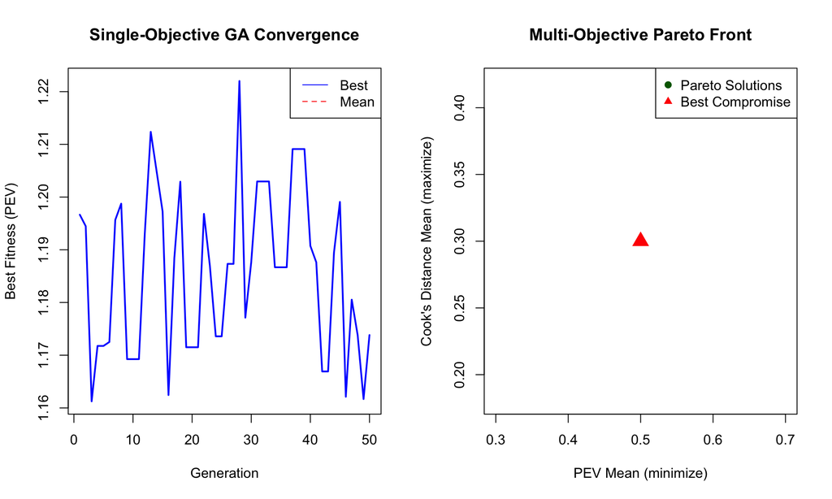

```r
# Plot GA results comparison
par(mfrow = c(1, 2))

# Single-objective convergence
plot(1:nrow(ga_basic$fitness_history), ga_basic$fitness_history[, "best"],
     type = "l", col = "blue", lwd = 2,
     xlab = "Generation", ylab = "Best Fitness (PEV)",
     main = "Single-Objective GA Convergence")
lines(1:nrow(ga_basic$fitness_history), ga_basic$fitness_history[, "mean"],
      col = "red", lty = 2)
legend("topright", c("Best", "Mean"), col = c("blue", "red"), lty = c(1, 2))
grid(TRUE)

# Multi-objective Pareto front
if (!is.null(archive_basic) && nrow(archive_basic) > 0) {
  plot(archive_basic[,1], archive_basic[,2], pch = 19, col = "darkgreen", cex = 1.2,
       xlab = "PEV Mean (minimize)", ylab = "Cook's Distance Mean (maximize)",
       main = "Multi-Objective Pareto Front")
  points(archive_basic[best_idx, 1], archive_basic[best_idx, 2],
         pch = 17, col = "red", cex = 2)
  legend("topright", c("Pareto Solutions", "Best Compromise"),
         pch = c(19, 17), col = c("darkgreen", "red"))
} else {
  plot(0.5, 0.3, pch = 19, col = "darkgreen", cex = 1.2,
       xlab = "PEV Mean (minimize)", ylab = "Cook's Distance Mean (maximize)",
       main = "Multi-Objective Pareto Front (No Solutions)")
  text(0.5, 0.25, "No Pareto solutions found", cex = 1.2)
}
grid(TRUE)
```

```r
par(mfrow = c(1, 1))
```

## Summary

The modernized STPGA package v7.0.0 provides: